[O’Hara on GitHub](https://github.com/oharac)

# Eco-Detectives: chapter 8

Compiled on Sat Dec 15 19:58:14 2018 by ohara

```r
knitr::opts_chunk$set(fig.width = 6, fig.height = 4, fig.path = 'Figs/',
                      echo = TRUE, message = FALSE, warning = FALSE)

source('https://raw.githubusercontent.com/oharac/src/master/R/common.R')
```

$\newcommand{\E}{\mathbb{E}} \newcommand{\Var}{\mathrm{Var}}$ $\newcommand{\L}{\mathscr{L}} \newcommand{\LL}{\mathscr{L}}$

# Chapter 8: Conservation biology of wildebeest in the Serengeti

## Pseudocode 8.1: Logistic Model

To determine best values of $r$ and $K$ (based on regular-year rainfall)

- input census data up to 1978 (means and std devs)
- Input starting estimates of params $r$, $K$, $N_1$
- Find vals of params that minimize neg log likelihood by these steps:
  - Predict values of $N_t$ from eq. 8.2:
    $$N_{t+1} = N_t + rN_t(1 - N_t/K)$$
  - For years in which census data are available, calc neg log likelihood using 8.4:
    $$\LL_t = \log(\sigma_t) + \frac{1}{2}\log 2\pi + \frac{(N_{obs,t} - N_t)^2}{2 \sigma_t^2}$$
  - Sum neg log likelihoods
  - Minimize total sum of neg log likelihoods over $r$ and $K$.

```r
calc_logistic <- function(N_t, r, K) {
  N_t_1 <- N_t + r * N_t * (1 - N_t / K)
  return(N_t_1)
}

calc_est_logistic <- function(N1, r, K, yrs) {
  N_vec <- vector(length = yrs)
  for(i in 1:yrs) {
    if(i == 1) {
      N_vec[i] <- N1
    } else {
      N_vec[i] <- calc_logistic(N_vec[i - 1], r, K)
    }
  }
  return(N_vec)
}

calc_nll_logistic <- function(sigma, N_obs, N_est) {
  ### pass vector of N_obs and N_est
  nll <- log(sigma) + .5 * log(2*pi) + (N_obs - N_est)^2 / (2 * sigma^2)
  return(sum(nll, na.rm = TRUE))
}

sum_nll_logistic <- function(par, N1, obs_data) {
  r <- par[1]; K <- par[2]
  ### create a vector of N_est
  N_est_vec <- calc_est_logistic(N1, r, K, yrs = nrow(obs_data))
  ### calc nll of this vector vs model
  sum_nll <- calc_nll_logistic(obs_data$N_sd, obs_data$N_mean, N_est_vec)
}
```

```r
observed_data <- read_csv('data/wildebeest_data.csv') %>%
  setNames(c('year', 'rain', 'N_mean', 'N_sd', 'M_adult', 'M_calf')) %>%
  mutate(N_sd = ifelse(is.na(N_sd) & year < 1970, 0.3 * N_mean, N_sd))
    ### assume CV before 1970 is 0.3, from page 186.

early_data <- observed_data %>%
  filter(year <= 1978 & year != 1960)

### choose some starting values
r_vec  <- seq(.05, .15, .001) ### should be about 0.10
N1_vec <- first(early_data$N_mean)
K_vec  <- c(10^seq(3, 10, 0.05))
  ### should be around 3.5e9 (thousand)! wtf

params_df <- crossing(N1_vec, r_vec, K_vec) %>%
  setNames(c('N1', 'r', 'K'))

nll_df <- params_df %>%
  rowwise() %>%
  mutate(nll = sum_nll_logistic(par = c(r, K), N1, early_data)) %>%
  ungroup()
```

Well OK those params don’t quite match the book’s estimates (i.e. doesn’t max out at K = 3.5e9). Here’s what I get: $N_1 = N_{1961} = 263; r = 0.103$; let’s just use $K = 3.5e9$ (essentially infinity - we’re just in exponential growth, not density-dependent growth here).

### using optim()

```r
### choose some starting values
r1 <- .05
N1 <- first(early_data$N_mean)
K1 <- 5000

z <- optim(par = c(r = r1, K = K1), fn = sum_nll_logistic, N1 = N1, obs_data = early_data)

z$par
```

```
##            r            K
## 1.030560e-01 2.559235e+08
```

### Fig. 8.4

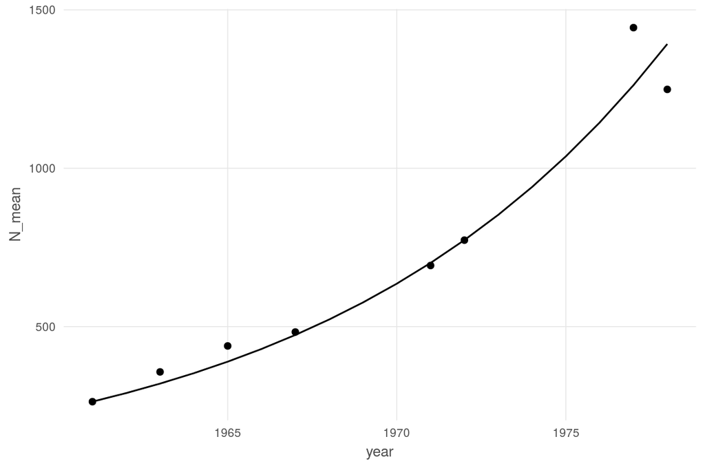

```r
n_plot_df <- early_data %>%
  mutate(N_est = calc_est_logistic(263, 0.103, 3.5e9, nrow(.)))

ggplot(n_plot_df, aes(x = year)) +
  geom_point(aes(y = N_mean)) +
  geom_line(aes(y = N_est)) +
  ggtheme_plot()
```

### Fig. 8.5 contour plot

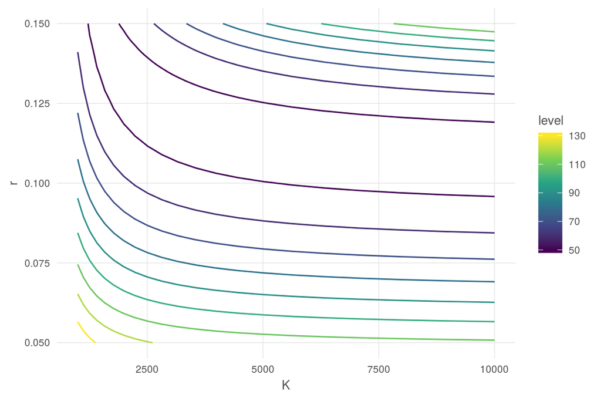

```r
ggplot(nll_df %>% filter(K <= 10000), aes(x = K, y = r, z = nll)) +
  geom_contour(aes(colour = stat(level))) +
  ggtheme_plot() +
  scale_color_viridis_c()
```

not sure why my plotted smooth and the book’s is rough. I call shenanigans - maybe just an artifact from the authors’ optimization function? since I did it numerically might be smoother?

## Pseudocode 8.2

- Input rainfall, census, calf surv, adult mort data and N1 up to 1978
- Input starting params of $a, b, f, g$
- Find values of params that minimize NLL by:
  - predict vals of $N_t$ and calf and adult survival from eq 8.10 (see below)
  - calc NLL for census data using single year terms in eq 8.11 (see below)
  - summing nll over all years
  - minimizing total sum

eq 8.11:
$$\begin{align*}
\LL_{\text{total}} &= \LL_{\text{census}} + \LL_{\text{calf survival}} + \LL_{\text{adult mortality}}\\
\LL_{\text{census}} &= \sum_t \frac{(N_t - N_{obs,t})^2}{2 \sigma_1^2}\\
\LL_{\text{calf survival}} &= \sum_t \frac{(s_{calf,t} - s_{calf,obs,t})^2}{2 \sigma_2^2}\\
\LL_{\text{adult mortality}} &= \sum_t \frac{(M_{adult,t} - M_{adult,obs,t})^2}{2 \sigma_3^2}
\end{align*}$$

Population dynamics including rainfall $R$, and accounting for survival of calves and adults.

$$\begin{align*}
T_t &= 1.25 R_t &\text{Food ~ rain (kg/ha-mo), eqn 8.5}\\
F_t &= \frac{T_t A}{N_t} &\text{Food per animal, eqn 8.6}\\
B_t &= 0.4N_t &\text{Births, eqn 8.7}\\
s_{calf,t} &= \frac{aF_t}{b+F_t} &\text{Calf surv. ~ food, eqn 8.8}\\
s_{adult,t} &= \frac{gF_t}{f+F_t} &\text{Adult surv. ~ food, eqn 8.9}\\[12pt]
N_{t+1} &= (s_{adult,t})N_t + (s_{calf,t})B_t;\\
N_{obs,t} &= N_t + V_t &\text{Pop dynamics, eqn 8.10}\\[12pt]
N_{t+1} &= N_t \left(\frac{g (1.25R_t/N_t)}{f + 1.25R_t/N_t}\right)
+ 0.4N_t \left(\frac{a (1.25R_t/N_t)}{b + 1.25R_t/N_t}\right)
&\text{Pop dynamics, eqn 8.12}
\end{align*}$$

```r
calc_8_12 <- function(par, R_t, N_t) {
  a <- par[1]; b <- par[2]; f <- par[3]; g <- par[4]

  N_t1 <- N_t * (g * 1.25 * R_t / N_t) / (f + 1.25 * R_t / N_t) +
    0.4 * N_t * (a * 1.25 * R_t / N_t) / (b + 1.25 * R_t / N_t)

  return(as.numeric(N_t1))
}

calc_est_8_12 <- function(par, data_df) {
  N_vec  <- vector('numeric', length = nrow(data_df)) ### population
  sc_vec <- vector('numeric', length = nrow(data_df)) ### calf surv
  sa_vec <- vector('numeric', length = nrow(data_df)) ### adult surv
  for(i in seq_along(N_vec)) {
    ### i <- 2
    if(i == 1) {
      N_vec[i] <- data_df$N_mean[1]
    } else {
      N_vec[i] <- calc_8_12(par, R_t = data_df$rain[i-1], N_t = N_vec[i-1])
        ### use last period's N and rain to determine this period's N
    }

  }

  ### with rain and N vectors, calc survival for calf and adult
  F_t <- 1.25 * data_df$rain * 1e6 / N_vec ### hard code area = 1e6 ha
  a <- par[1]; b <- par[2]; f <- par[3]; g <- par[4]
  sc_vec <- a * F_t / (b + F_t)
  sa_vec <- g * F_t / (f + F_t)

  df <- data_df %>%
    mutate(N_est   = N_vec,
           s_calf  = sc_vec,
           s_adult = sa_vec)
  return(df)
}

calc_nll_8_12 <- function(par, data_df) {
  ### check parameters are positive; else return NA.  This is
  ### a way to force the optim() function to stay within constraints.
  ### Can also look into constrOptim()?
  ### NOTE: changed lower bound to .001 instead of zero, just to
  ### see if it improves smoothness by eliminating weird tiny numeric BS
  if(all(par > 0.001) & par[2] >= 0.1) {
    ### all OK; use params to estimate N, s_calf, s_adult, and bind to data_df
    df <- calc_est_8_12(par, data_df)

    if(any(df$N_est <= 0)) {
      ### constrain population estimates to be positive
      return(NA)
    }

    ### operate on the vectors of each parameter in the data frame
    nll_census <- (df$N_est - df$N_mean)^2 / (2 * df$N_sd^2)
    nll_calf   <- ((1 - df$s_calf) - df$M_calf)^2 / (2 * df$sd_calf^2)
      ### calf mortality is 1 - survival
    nll_adult  <- ((1 - df$s_adult^.25) - df$M_adult)^2 / (2 * df$sd_adult^2)
      ### adult mortality is measured per month of dry season, so the estimate
      ### of M_{adult,t} = 1 - (s_{adult,t})^.25 per page 195.

    ### the values won't line up by year, but summing across all
    ### non-NA values should still give us a minimizable value.
    nll_sum <- sum(c(nll_census, nll_calf, nll_adult), na.rm = TRUE)

    return(nll_sum)
  } else {
    return(NA)
  }
}
```

### Optimize parameters

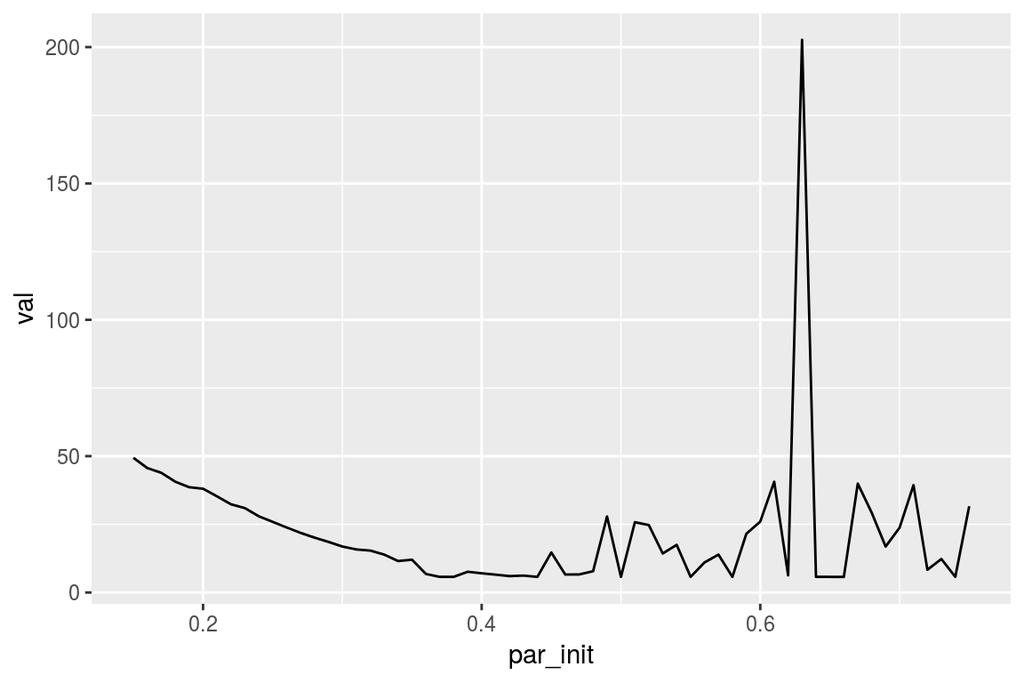

```r
observed_data <- read_csv('data/wildebeest_data.csv') %>%
  setNames(c('year', 'rain', 'N_mean', 'N_sd', 'M_adult', 'M_calf')) %>%
  mutate(N_sd = ifelse(is.na(N_sd) & year < 1970, 0.3 * N_mean, N_sd))
    ### assume CV before 1970 is 0.3, from page 186.

early_data <- observed_data %>%
  filter(year <= 1978 & year != 1960) %>%
  mutate(sd_adult = sd(M_adult, na.rm = TRUE),
         sd_calf  = sd(M_calf, na.rm = TRUE))

z_df <- data.frame()
for(p in seq(.15, .75, .01)) {

  init_pars <- c(a = p, b = p, f = p, g = p)

  tmp <- optim(par = init_pars, fn = calc_nll_8_12, data_df = early_data)

  tmp_df <- data.frame(par_init = p,
                       a = tmp$par[1],
                       b = tmp$par[2],
                       f = tmp$par[3],
                       g = tmp$par[4],
                       val = tmp$value)
  z_df <- bind_rows(z_df, tmp_df)
}

ggplot(z_df, aes(x = par_init, y = val)) + geom_line()
```

Note that the optimized parameters seem *very* noisy and/or sensitive to the starting parameters.

### Fig. 8.6

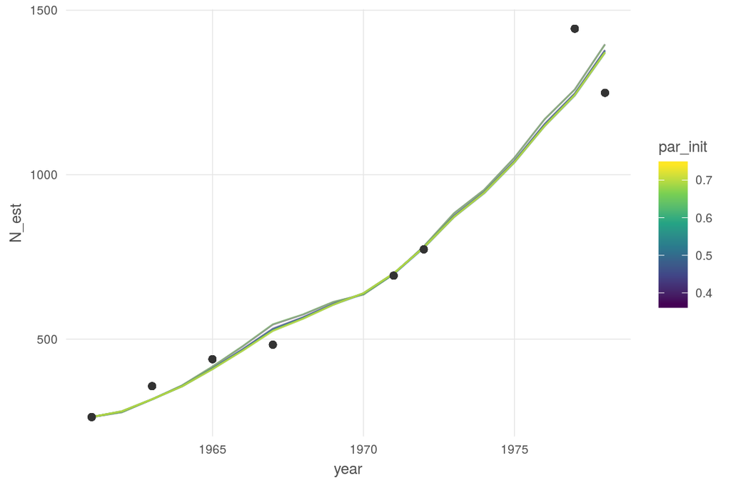

```r
### Sort by lowest-highest, and take the 10 minimum values for comparison
opt_param_df <- z_df %>%
  arrange(val) %>%
  .[1:10, ]
optimized_df <- lapply(1:10, FUN = function(j) { # j <- 1
    par <- as.numeric(opt_param_df[j, 2:5])
    y <- calc_est_8_12(par, early_data) %>%
      mutate(par_init = opt_param_df[j, 1])
  }) %>%
  bind_rows()

ggplot(optimized_df, aes(x = year, color = par_init)) +
  geom_line(aes(y = N_est, group = par_init), alpha = .5) +
  geom_point(aes(y = N_mean), color = 'grey20') +
  scale_color_viridis_c() +
  ggtheme_plot()
```

### Solve for equil population

Solving for equilibrium pop ($N_{t+1} = N_t = N_{eq}$):
$$N_{eq} = \frac{-b' + \sqrt{b'^2 - 4a'c'}}{2a'}$$
where $a' = bf, b' = 1.25R(b+f-gb-0.4af), c' = (1.25R)^2(1-g-0.4a)$.

```r
R_eq <- 150 ### dry year equilibrium

calc_equil_pop <- function(a, b, f, g, R_eq) {
  a1 = b * f
  b1 = 1.25 * R_eq * (b + f - g*b - 0.4*a*f)
  c1 = (1.25 * R_eq)^2 * (1 - g - 0.4*a)
  N_eq = (-b1 + sqrt(b1^2 - 4*a1*c1)) / (2*a1)
  return(N_eq)
}

N_eq_df <- opt_param_df %>%
  mutate(N_eq = calc_equil_pop(a, b, f, g, R_eq))

knitr::kable(N_eq_df)
```

| par_init | a | b | f | g | val | N_eq |
| --- | --- | --- | --- | --- | --- | --- |
| 0.66 | 0.6621508 | 0.1060524 | 0.0139882 | 0.9566011 | 5.710815 | 1535.819 |
| 0.44 | 0.6619112 | 0.1824235 | 0.0049750 | 0.9565532 | 5.725309 | 1966.509 |
| 0.37 | 0.6625790 | 0.1947261 | 0.0039331 | 0.9567133 | 5.728462 | 2092.690 |
| 0.55 | 0.6622684 | 0.2033308 | 0.0031072 | 0.9565343 | 5.730969 | 2228.531 |
| 0.58 | 0.6623018 | 0.2142055 | 0.0022765 | 0.9567452 | 5.733989 | 2414.037 |
| 0.74 | 0.6621508 | 0.2229362 | 0.0015099 | 0.9565716 | 5.736752 | 2665.374 |
| 0.64 | 0.6620586 | 0.2258534 | 0.0012855 | 0.9566136 | 5.737657 | 2763.668 |
| 0.65 | 0.6622247 | 0.2265091 | 0.0012395 | 0.9565790 | 5.737822 | 2784.118 |
| 0.50 | 0.6586859 | 0.1971401 | 0.0036639 | 0.9569506 | 5.742087 | 2130.991 |
| 0.38 | 0.6539952 | 0.1000000 | 0.0142934 | 0.9570059 | 5.754053 | 1540.903 |

```r
# mean(N_eq_df$a) # [1] 0.6610326
# sd(N_eq_df$a) # 0.002714316   CV(a) = .0041
# mean(N_eq_df$g) # [1] 0.9566868
# sd(N_eq_df$g) # 0.0001680789   CV(g) = .00018
# mean(N_eq_df$b) # [1] 0.1873177
# sd(N_eq_df$b) # 0.04675319   CV(b) = .25
# mean(N_eq_df$f) # [1] 0.005027211
# sd(N_eq_df$f) # 0.004957489   CV(f) = .99
```

According to these sets of optimized parameters, the 150mm rainfall equilibrium pop will be anywhere from 1.5 to 4.1 million (if params lower bound is 0; brings values in significantly if lower bound on params is 0.001 as is done here). The text says 1.8 million. Since the text does not provide any insights on the optimal params (except for their constraints), tough to compare.

Note that $a$ and $g$ params seem pretty consistent, but the $f$ and $b$ terms are all over the place. What if we fixed $a$ and $g$ and then re-optimized?

**NOTE:** still pretty unstable. `constrOptim()` maybe?

## Pseudocode 8.3 Confidence in N_eq

Want to find the likelihood profile of our equilibrium population $N_{eq}$ (carrying capacity). It’s not a parameter of our model, so we can’t just calc MLE for different values. Instead, we constrain the estimation procedure to find values of $a, b, f, g$ that maximize the likelihood given a specific equil pop. To do this, set a penalty based on the target equil pop and the calculated equil pop with those parameters:
$$P(N_{eq}, N_{target}) = \frac{(N_{eq} - N_{target})^{\gamma}}{M}$$
where $\gamma$ and $M$ are params used to set the size of the penalty. Then, maximize the sum of the three likelihoods plus the penalty. In effect, find best fit constrained so that the equil pop is very close to $N_{target}$.

- Input rainfall, census, calf survival, and adult mort data.
- Input starting estimates of params $a, b, f, g$.
- Input a range of vals of $N_{target}$ over which to search.
- Loop over vals of $N_{target}$ and find param vals that minimize sum of NLL plus penalty function.
  - here we *minimize* $\sum$NLL plus penalty, not maximize?
- Plot NLL vs $N_{target}$.
  - without penalty?

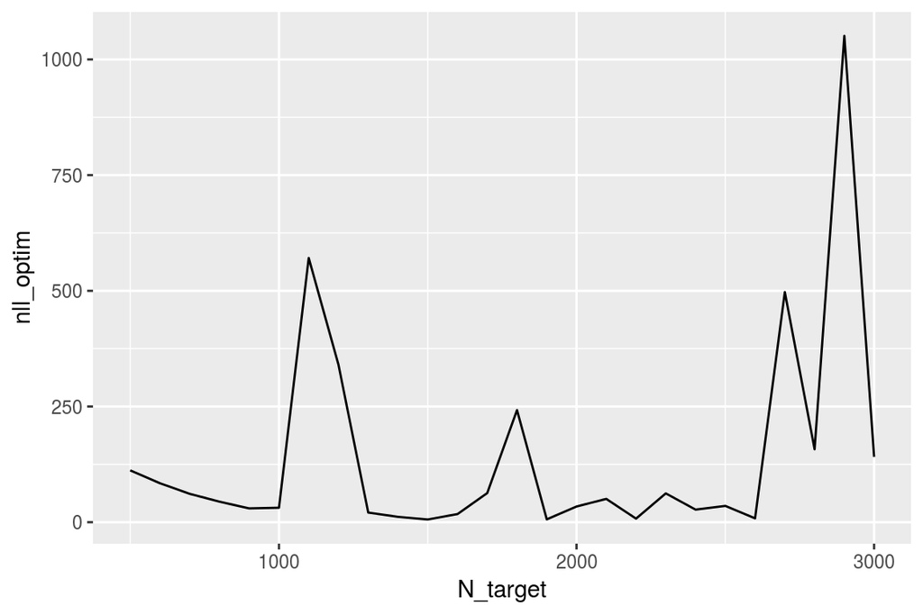

```r
observed_data <- read_csv('data/wildebeest_data.csv') %>%
  setNames(c('year', 'rain', 'N_mean', 'N_sd', 'M_adult', 'M_calf')) %>%
  mutate(N_sd = ifelse(is.na(N_sd) & year < 1970, 0.3 * N_mean, N_sd))
    ### assume CV before 1970 is 0.3, from page 186.

early_data <- observed_data %>%
  filter(year <= 1978 & year != 1960) %>%
  mutate(sd_adult = sd(M_adult, na.rm = TRUE),
         sd_calf  = sd(M_calf, na.rm = TRUE))

R_eq <- 150
gamma <- 2
M <- 100

calc_nll_w_penalty <- function(par, data_df, N_target, M, gamma) {
  nll_raw <- calc_nll_8_12(par, data_df)
  N_eq <- calc_equil_pop(par[1], par[2], par[3], par[4], R_eq)
  penalty <- (N_eq - N_target)^gamma / M

  return(nll_raw + penalty)
}


init_pars <- c(.3, .3, .3, .3)

N_target_vec <- seq(500, 3000, 100)
N_eq_likelihood_df <- data.frame()
for(N_target in N_target_vec) {
  ### N_target <- N_target_vec[1]
  z <- optim(par = init_pars, fn = calc_nll_w_penalty,
             data_df = early_data, N_target = N_target, M = M, gamma = gamma)
  tmp_df <- data.frame(N_target = N_target,
                       nll_optim = calc_nll_8_12(z$par, early_data))
  N_eq_likelihood_df <- N_eq_likelihood_df %>% bind_rows(tmp_df)
}

ggplot(N_eq_likelihood_df, aes(x = N_target, y = nll_optim)) +
  geom_line()
```